# ProjektR

Ema Perkovic

05/05/2022

# Uvod

Motivacija tega projekta je pridobiti več informacij o vplivu ozadja staršev, priprav na izpite in drugih dejavnikov na uspešnost učencev s pomočjo nabora podatkov, ki ima 1 000 vrstic in 8 stolpcev. Katere vse značilnosti imajo odločilno vlogo pri vplivu na učenčevo uspešnost.

# Predstavitev in prezentacija podatkov

Podatki uporabljeni pri tej analizi so bili pridobljeni s spletne strani [Kaggle.com](https://www.kaggle.com/code/suchitakumari/student-performance-analysis). Podatki so bili zbrani v srednjih šolah v Združenih državah Amerike v letu 2019.5 stolpcev je kategoričnih in 3 stolpci so številčne spremenljivke. Podatki so sestavljeni iz 1000 učencev in 8 stolpcev:

- 1.spol
- 2.rasa/etnična pripadnost
- 3.stopnja izobrazbe staršev
- 4.kosilo
- 5.priprave na izpit
- 6.matematični rezultat
- 7.rezultat pri branju
- 8.rezultat pri pisanju

Pri podatkih tipa kot so matematični rezultat,rezultat pri branju in pisanju sem uporabila naslednjo ocenjavalno lestvico:

- A:100%-91%
- B:90%-81%
- C:80%-71%
- D:70%-61%
- E:60%-50%
- F:>50%

# Analiza podatkov

### Ali en spol prekaša drugega v vseh rezultatih?

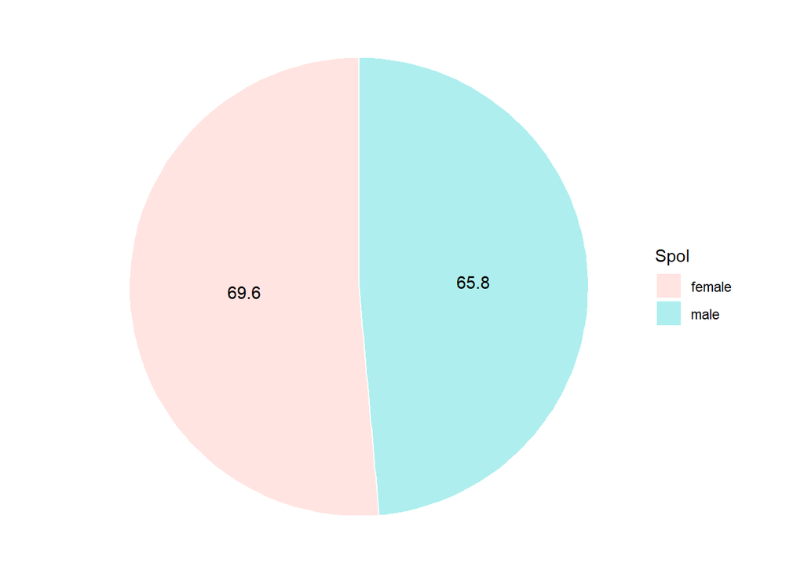

Za odgovor na to vprašanje se izračuna povprečje vseh treh rezultatov (matematični rezultat + bralni rezultat + pisni rezultat), rezultati pa se prikažejo s tortnim diagramom. Iz grafa je razvidno, da imajo ženske višji povprečni rezultat kot moški.

### Ali imajo podatki kakršno koli korelacijo

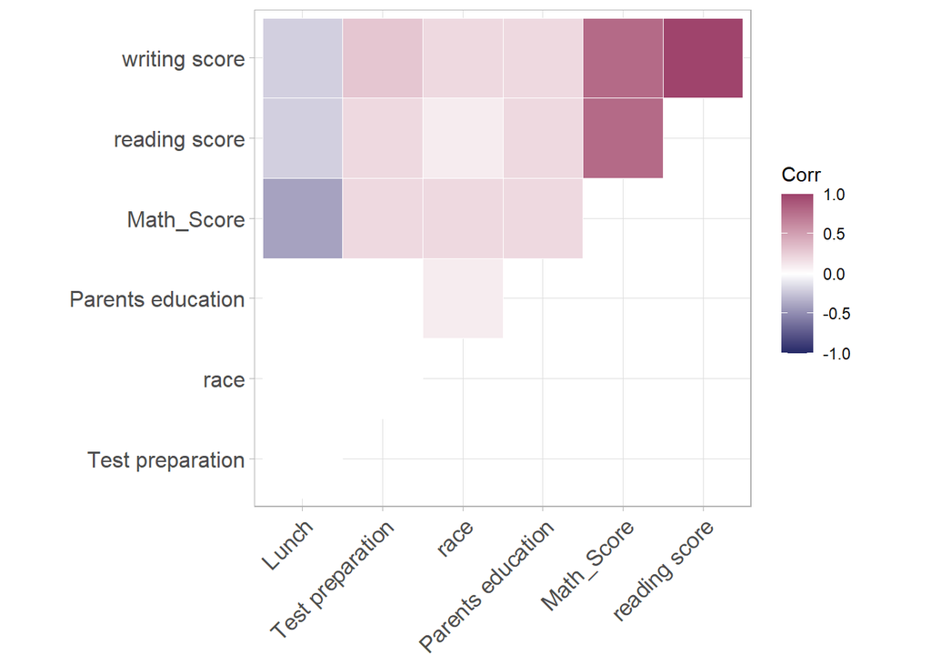

Med rezultati branja, pisanja in matematike obstajajo močne pozitivne korelacije.Iz diagrama je jasno videti, da imata najmočnejo korelacijo pisalni in bralni rezultat. Kosilo, rasa ter priprava na izpit imajo korelacijo enako 0. Kosilo bolj vpliva na matematične rezultate kot pa na bralne in pisalne. Na drugi strani pa na pisalne rezultate bolj vpliva priprava na izpit, kot pa na matematične in bralne. Rasa ima večjo prisotnost pri matematičnih in pisalnih rezultatih kot pa pri bralnih. Izobrazba staršev pa na vse tri vpliva enakomerno ter tudi na skupino rase.

### Ali se učenci s standardnim kosilom bolje izkažejo pri matematičnih rezultatih?

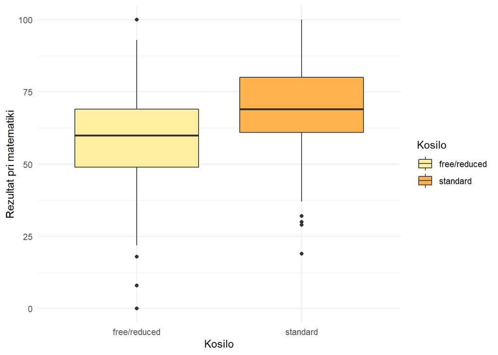

Jasno je, da imajo učenci s standardnim kosilom boljše ocene.

### Ali priprava na izpit vpliva na rezultate pri matematiki?

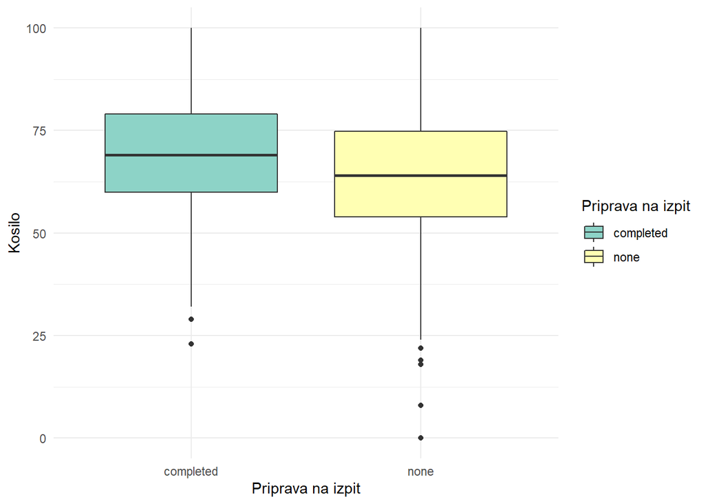

Da,kot predvideno so se učenci, ki so se na izpit pripravljali, na koncu boljše izkazali.

### Ali je posamezna rasa boljša od ostalih v matematiki?

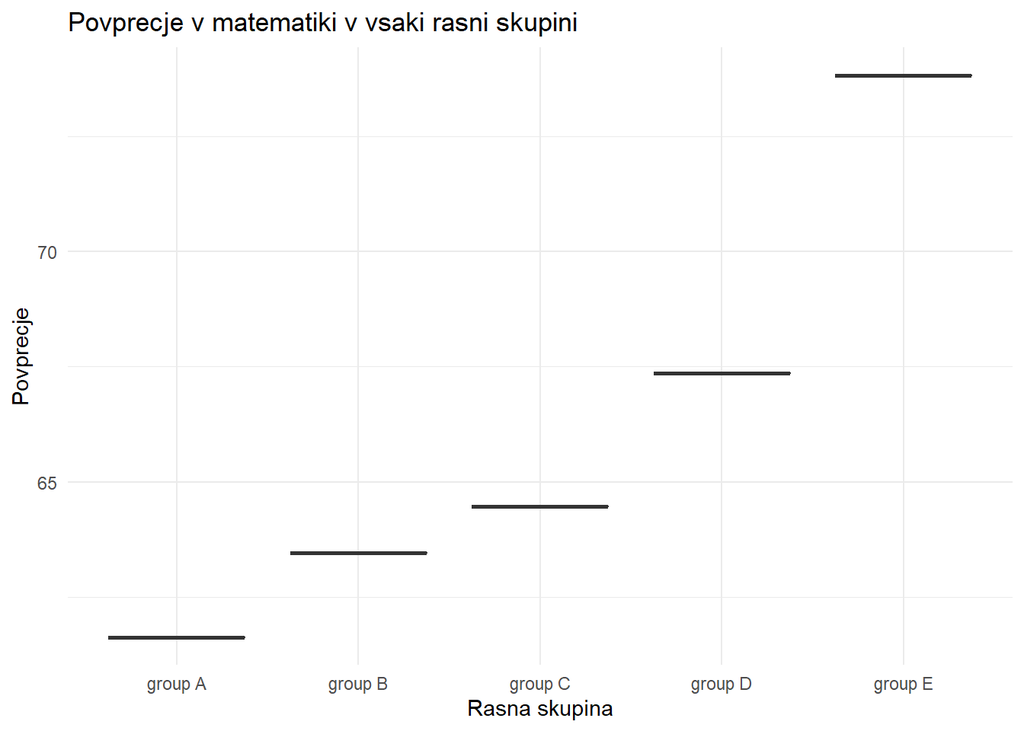

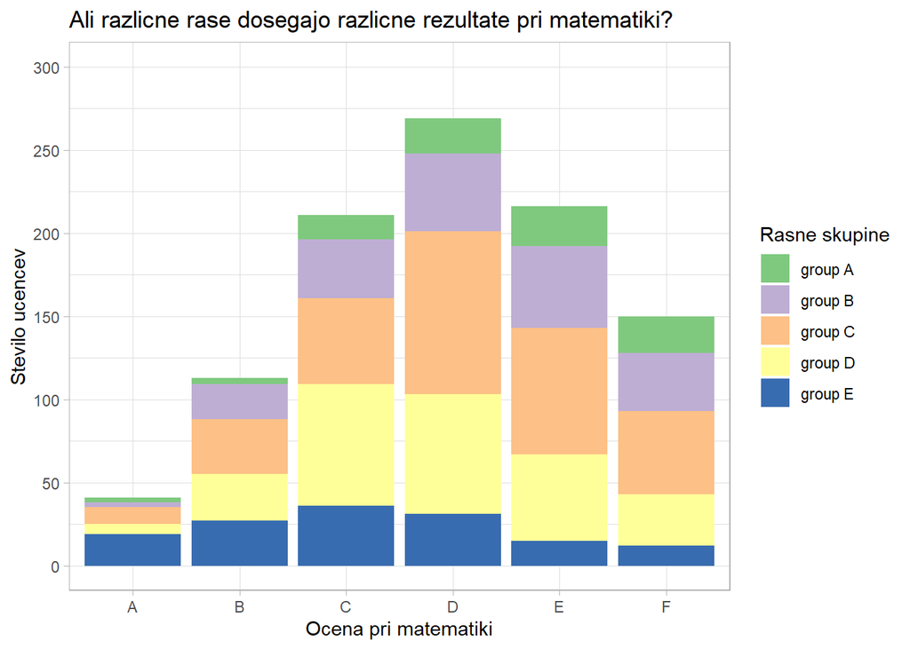